# Italy Spread Analysis during PIIGS Sovereign debt crisis

Giuseppe Di Poce matr:2072371

2023-07-28

[figure not shown]

PIIGS…Whatever it takes…

## Problem Description

In this analysis we will focus our attention on the situation of the bond prices and yields of the main European countries during the sovereign debt crisis that exploded in 2011. Specifically, we will broadly analyze the situation of the PIIGS (Portugal, Italy, Ireland, Greece and Spain), focusing on the Italian debt scenario, taking in consideration the BTP-BUND ratio (Spread) as an important variable for our analysis.
$Spread$ is defined as the difference among the return in bases points of the yields of a county of the Eurozone and the Deutschland returns (leader country). It is computed only over the 10 years expiry bonds and can be summarized as follow for the italian case:
$$SPREAD = BTP_{10y} -
BUND_{10y}$$
$\textit{In summary, to explain what the Btp-Bund spread is, we can state that it is a value that tells us how much dangerous it is to lend money to the Italian State (by buying Btp) compared to buying the Bund.}$

### What is the Sovereign crisis?

In a nutshell, we can summarize the sovereign crisis as an event due to the speculative bubble of the subprimes of 2007 (Lehman brothers bankruptcy): the main European state banks had serious difficulties and were saved by public interventions, thus triggering a serious situation of public finance imbalances for weaker countries, starting a domino effect that led to the risk of the fall of the whole Euro-zone.

## Whatever it takes…

The monetary policy that ended the crisis, after the actualization of many others, was announced by Mario Draghi in his famous ‘whatever it takes’ speech. In autumn 2014 he announced a plan to purchase bonds for 1,100 billion euros, the so-called “Quantitative Easing”, which supported the European government bond market and put the end to the sovereign debt crisis. This prior ‘historical’ information will be so much useful when we will implement a CP analysis.

## Data

```r
head(yields_EU) #PIIGS
```

```
##            time  DE05  DE10  DE30   GR05   GR10  IE05  IE10  IT05  IT10  IT30
## 2935 2012-01-03 0.824 1.913 2.490 51.694 33.970 7.712 8.507 5.903 6.929 6.762
## 2936 2012-01-04 0.811 1.903 2.482 50.196 34.244 7.808 8.372 5.907 6.929 6.827
## 2937 2012-01-05 0.779 1.856 2.426 50.209 34.322 7.447 8.273 6.099 7.053 6.999
## 2938 2012-01-06 0.778 1.850 2.439 50.209 34.322 7.300 8.258 6.286 7.136 7.077
## 2939 2012-01-09 0.783 1.860 2.468 51.385 34.327 7.479 8.259 6.370 7.146 7.104
## 2940 2012-01-10 0.814 1.867 2.466 51.335 34.273 7.124 8.142 6.395 7.126 7.076
##        PT05   PT10 ES05  ES10  ES30
## 2935 16.519 13.469 4.46 5.297 6.080
## 2936 16.524 13.462 4.49 5.459 6.203
## 2937 16.525 13.486 4.73 5.644 6.367
## 2938 16.000 13.318 4.93 5.747 6.399
## 2939 16.092 13.252 4.69 5.587 6.319
## 2940 15.826 13.002 4.57 5.495 6.259
```

$$YIELDS$$

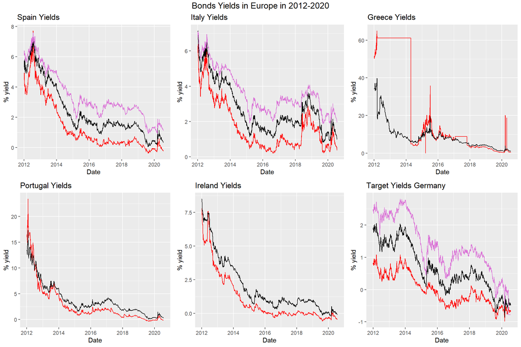

As you can briefly notice shapes of time series are very different among countries, highlighting a strong different behavior w.r.t. Germany yields, the lower ones. The higher the yields, the more it means that the bonds of that country are $risky$ $investments$ and therefore that they yield more.  
Let’s have a look to the $prices$ data:

$$PRICES$$

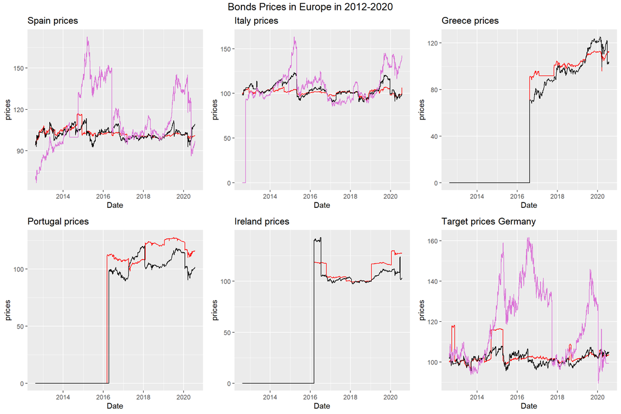

After this kind of introduction of the Euro-zone debt , we can focus our attention on a specific PIIGS: Italy.

For the purposes of our analysis we are interested to use Bayesian modeling to :  
- retrieve an estimation of volatility of Italian Bond prices in the interim period between the sovereign debt crisis and the stabilization of the new quantitative easing monetary policy. Such volatility is an estimation that quantifies the degree of fluctuation and uncertainty, and this can be translated into terms of relative $RISK$ in the market attached to our country.  
- find key change point(CP) in the spread trend, helping us to identify them thanks to prior knowledge of the main monetary policies of BCE.

```
##            time  DE05  DE10  DE30  IT05  IT10  IT30
## 2935 2012-01-03 0.824 1.913 2.490 5.903 6.929 6.762
## 2936 2012-01-04 0.811 1.903 2.482 5.907 6.929 6.827
## 2937 2012-01-05 0.779 1.856 2.426 6.099 7.053 6.999
## 2938 2012-01-06 0.778 1.850 2.439 6.286 7.136 7.077
## 2939 2012-01-09 0.783 1.860 2.468 6.370 7.146 7.104
## 2940 2012-01-10 0.814 1.867 2.466 6.395 7.126 7.076
```

Compute the spread over all our year maturity, but claim that it is referred just over 10 years exipiration.  
After filtering our data of yields just on Italy features and extract the spread values,data with we are dealing with appears like this:

```r
df$BTP_BUND_05 <- (df$IT05-df$DE05 )
df$BTP_BUND_10 <- (df$IT10-df$DE10 ) #notice that the REAL spread is computed only onto 10 years btp-bund
df$BTP_BUND_30 <- (df$IT30 -df$DE30 )
head(df)
```

```
##            time  DE05  DE10  DE30  IT05  IT10  IT30 BTP_BUND_05 BTP_BUND_10
## 2935 2012-01-03 0.824 1.913 2.490 5.903 6.929 6.762       5.079       5.016
## 2936 2012-01-04 0.811 1.903 2.482 5.907 6.929 6.827       5.096       5.026
## 2937 2012-01-05 0.779 1.856 2.426 6.099 7.053 6.999       5.320       5.197
## 2938 2012-01-06 0.778 1.850 2.439 6.286 7.136 7.077       5.508       5.286
## 2939 2012-01-09 0.783 1.860 2.468 6.370 7.146 7.104       5.587       5.286
## 2940 2012-01-10 0.814 1.867 2.466 6.395 7.126 7.076       5.581       5.259
##      BTP_BUND_30
## 2935       4.272
## 2936       4.345
## 2937       4.573
## 2938       4.638
## 2939       4.636
## 2940       4.610
```

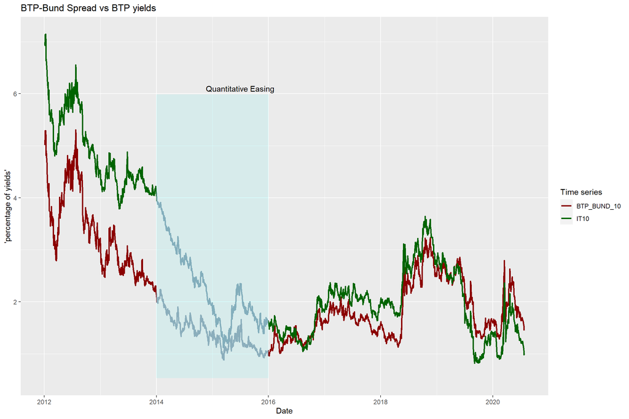

and let’s also visualize the dependent variable (Spread) versus BTP. Can we notice some pattern or dependence?

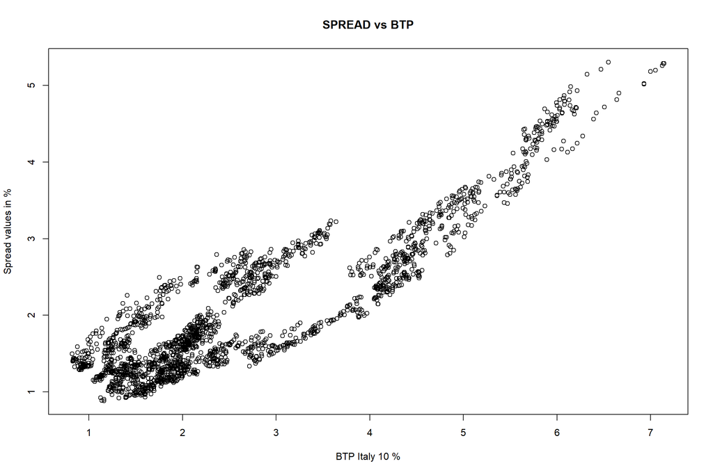

## Spread time series inspection

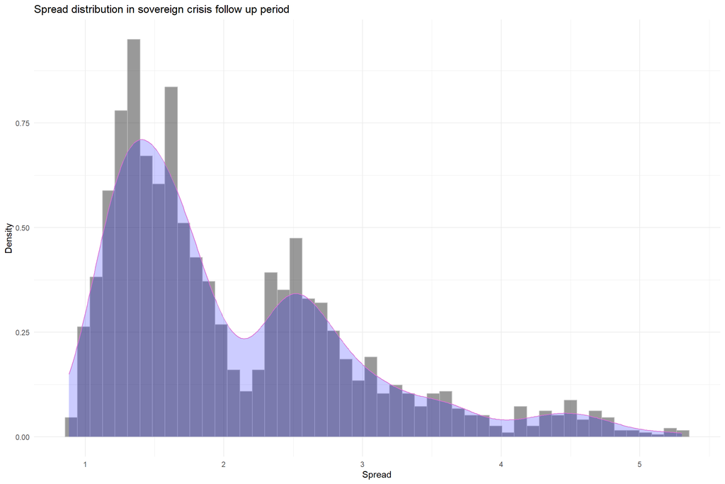

Obviously not symmetrical distribution and difficultly traceable to a known distribution. It seems to be a bimodal distribution but it is not traceable to a known distribution.

Check seasonality in data : the “multiplicative” model is used when the seasonal variation increases or decreases over time.

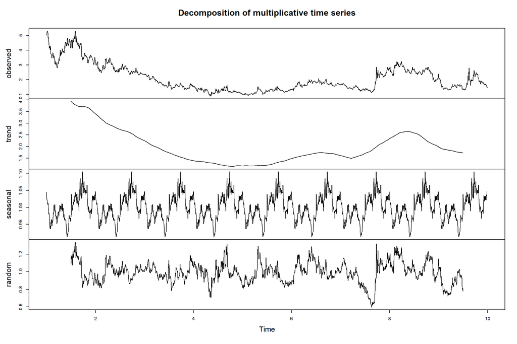

```r
colss<-c('time','BTP_BUND_05','BTP_BUND_10','BTP_BUND_30')
ts_spread <- df[,'BTP_BUND_10']
ts <- ts(ts_spread,frequency = mean(observations_per_year$Observations))
decomposedRes <- decompose(ts, type="multiplicative")
plot(decomposedRes)
```

From this decomposition we can conclude that there is no clear seasonality or a well defined trend. The randomness (the residuals) represents the random fluctuations present in the data, which cannot be attributed to any specific pattern. In our case the random do not follow a specific pattern but we can notice in the trend an up and down shape, with a clear minimum among the 4 and 6 time index.

$$CHANGE \,\,\, POINTS$$
Bayesian change point analysis is a statistical approach used to identify abrupt changes or breakpoints in time series data.
The primary purpose of Bayesian change point analysis is to identify the points in time where there are significant shifts or changes in the underlying structure of the data-generating process.
$Important$:
For the purposes of our analysis we are interested to understand not just to identify cp w.r.t. Spread data, we want to investigate among the relationship between BTP-BUND and BTP and discover relevant break-point.

### The regression model with one CP

To specify the model with a single change point, consider a sample size of $n$, with response data $y_1, \ldots, y_n$ observed at continuous times $x_1, \ldots, x_n$ with $x_1 < x_2 < \ldots < x_n$. In the simplest regression case of a single $\mathrm{CP}$ we have:

$$y_i \sim N(\mu_i,\sigma^2_1); x_i <
\gamma$$
$$y_i \sim
N(\mu_i,\sigma^2_1+\sigma^2_2)$$

$$\mu_{y_i} = \begin{cases}
\alpha + \beta_1 x_i + \epsilon_i & \text{when } x_i < \gamma, \\
\alpha_1+\alpha_2 +(\beta_1+ \beta_2) x_i + \epsilon_i &
\text{otherwise.}
\end{cases}$$

Here: - $\alpha$ is the intercept off the regression,  
- $\epsilon_i \sim N(0, \sigma^2)$ and $\sigma^2$ is the residual variance,  
- Most importantly, $\gamma$ is the time value where a change in rate occurs, and  
- $\beta_1$ and $\beta_2$ are the slopes before and after the trend change.

```r
set.seed(29011998) # yes that's my birth date
n <- length(spread$IT10) # number of total data points
x <- spread$IT10  # predictor is btp yields
y <- spread$BTP_BUND_10 # dependent variable is the spread % value
```

The goal is to fit two regressions, one before and one after the detected change point in n iterations. The code above implement our cp model assuming our dependent variable : $y_i \sim N(\mu_i,\tau_i)$ where JAGS assume a $precision$ of $\tau=\frac{1}{\sigma^2}$.  
Furthermore we need to specify priors for all parameters that are not specified by data. $\alpha_1 \sim N\left(\mu=0, \tau=10^{-4}\right)$ That is a normal distribution with mean $\mu=0$ and standard deviation $\sigma=100$, because $\sigma=1 / \sqrt{\tau}$ . Log-transformation is used to ensure that the $\tau$ resulting from $\tau_1$ and $\tau_2$ is positive. The prior information about K probability is a uniform one set as $\frac{1}{n.data points}$ … means that we have no prior information! But please notice again that we are narrowing the area due to the fact that we know that the main change point may be among 2014 and 2016.

```r
model_CPR <- function(){
  ### Likelihood or data model part
  for(i in 1:n){
  y[i] ~ dnorm(mu[i], tau[i])

  mu[i] <- alpha_1 +
  alpha_2 * step(i - n_change) +
  (beta_1 + beta_2 * step(i - n_change))*x[i]

  tau <- exp(log_tau[i])

  log_tau[i] <- log_tau_1 + log_tau_2 *
  step(i - n_change)
  }
  ### Priors
  alpha_1 ~ dnorm(0, 1.0E-4) #high variance , JAGS works with precision (inverse of variance)
  alpha_2 ~ dnorm(0, 1.0E-4) #is a normal distribution with mean mu=0 and standard deviation = 100

  beta_1 ~ dnorm(0, 1.0E-4)
  beta_2 ~ dnorm(0, 1.0E-4)
  log_tau_1 ~ dnorm(0, 1.0E-4)
  log_tau_2 ~ dnorm(0, 1.0E-4)
  K ~ dcat(p)
  n_change <- possible_change_points[K]
}
```

```r
# #1 CP DETECTION
# start.time <- Sys.time()
#
# CPR_prova  <- jags(data = data_CPR,
#              parameters.to.save = c("alpha_1", "alpha_2",
#                                     "beta_1","beta_2",
#                                     "log_tau_1","log_tau_2",
#                                     "n_change"),
#              n.iter = 1500,
#              n.chains = 3,
#              model.file = model_CPR)
#
# end.time <- Sys.time()
#
# time.taken <- end.time - start.time
# print(paste("Time taken: ", time.taken))
# # Save the CPR object as an R Data file
# save(CPR_prova, file = "CPR.RData")
# #
```

```r
# Load the CPR object from the R Data file
load("CPR_2kiterazioni.RData")
#print(CPR)
```

From the following plots we can analyze the results of our CP model.  
Basically it converge among 690 and 700 (number of data point indexes). The $\alpha$ (intercept) parameters distinguish a positive intercept after the changepoint and a negative one before. It is also interesting notice that the parameter $\beta_2$ is negative after the breakpoint and so that $\beta$ after the change point result with a lower value w.r.t. before cp.

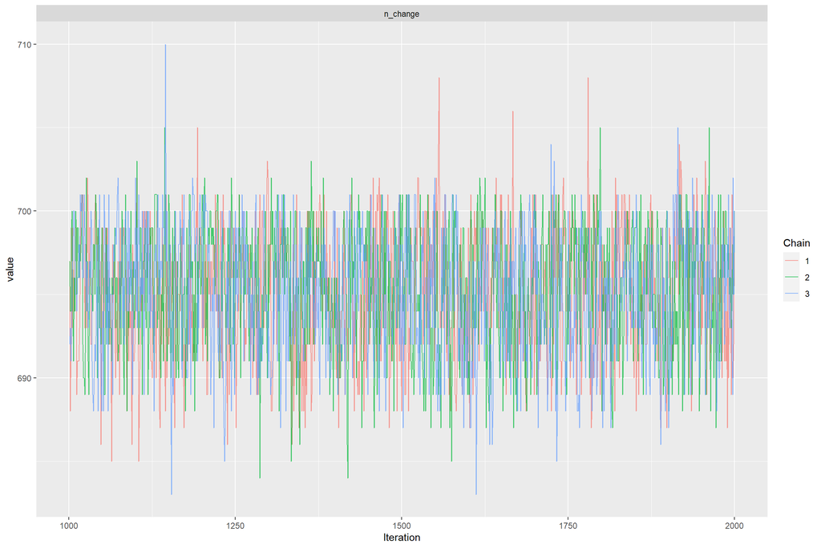

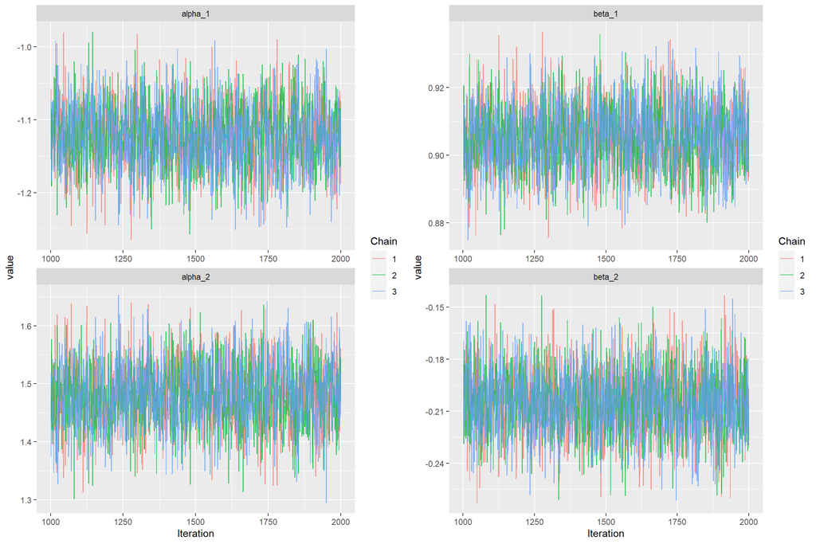

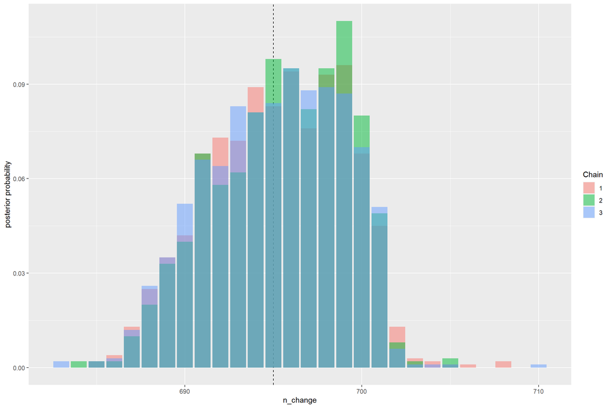

In which interval does the change point fall with 90 % probability?

```
## [1] "The change point fall with 90% probability among 689 and 701 so among 2014-09-29 and 2014-10-15"
```

And infact the act that characterizes the Draghi presidency is therefore the launch of the massive purchase program of securities which goes under the name of Quantitative Easing, which was announced in the autumn of 2014 and began in March 2015. Here a historical resume… So proud of this!!!!

[Click Here to see Mario](https://www.youtube.com/watch?v=ItcqFRMF1Q0)

```r
# The probability that the change point falls in the interval pmin to pmax:
prob = round(length(which(CPR$BUGSoutput$sims.list$n_change %in% pmin:pmax))/(CPR$BUGSoutput$n.sims),2)
print(paste('There is',prob,'probabilty that change point falls in the interval',date1,'-', date2 ))
```

```
## [1] "There is 0.94 probabilty that change point falls in the interval 2014-09-29 - 2014-10-15"
```

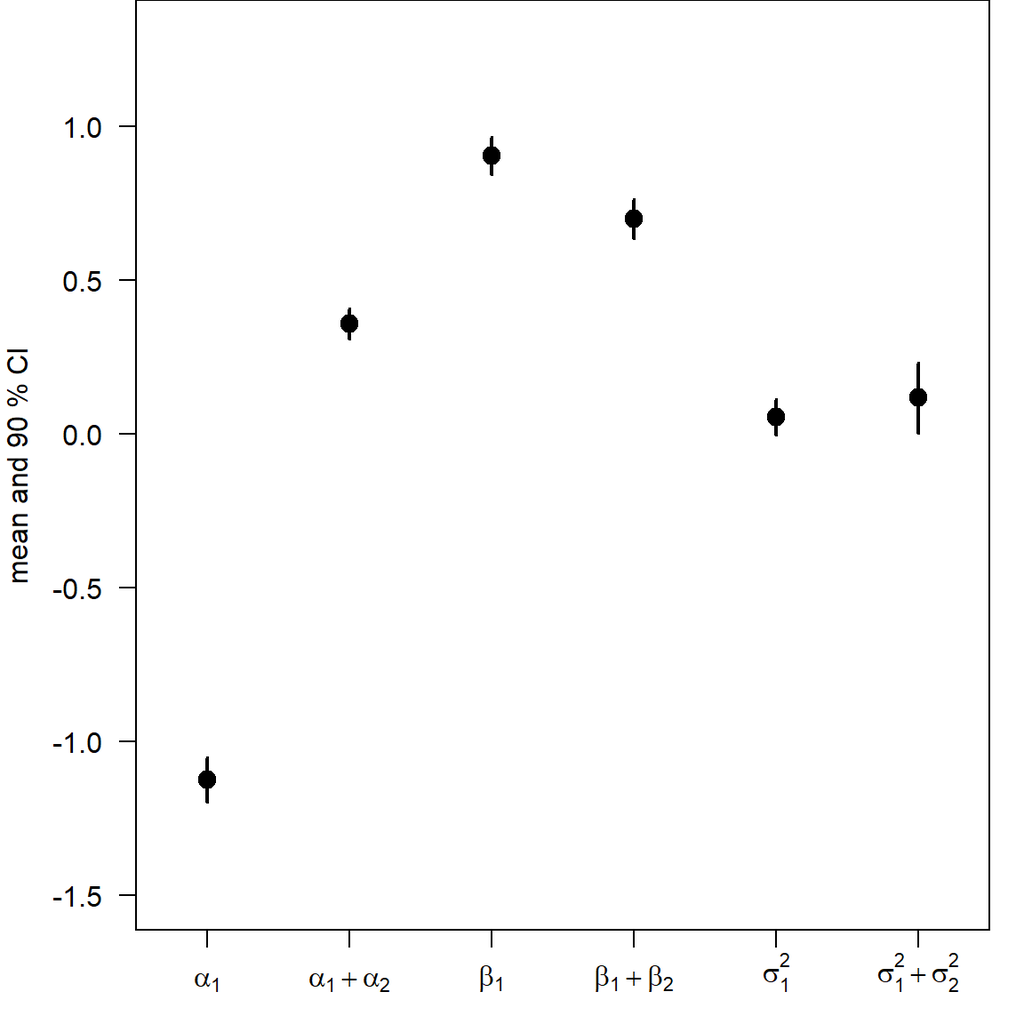

Notice that the slope decrease after the change point!

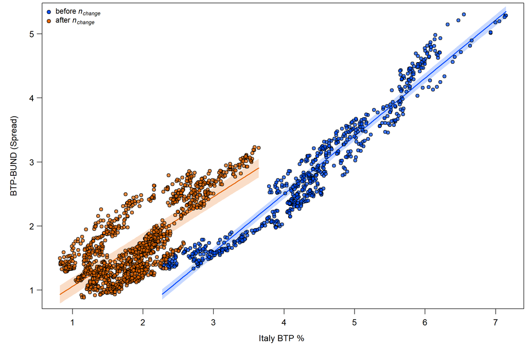

Now it’s time to focus our attention on the prices data, analyzing the risk in terms of volatility durings PIIGS period.

$$VOLATILITY$$
$Volatility$ is a crucial risk factor in financial markets, impacting investors, traders and the stability of the financial system. When analyzing prices time series data, considering volatility becomes important to understand how market conditions influence the relationships between financial instruments. $\textbf{Estimate the volatility for our purposes is crucial to understand the variability wherewith is dangerous to lend money to the Italian State (by buying Btp) compared to buying the Bund.}$ It may be a useful indicator for financial market operators.

The time series for prices is the following:

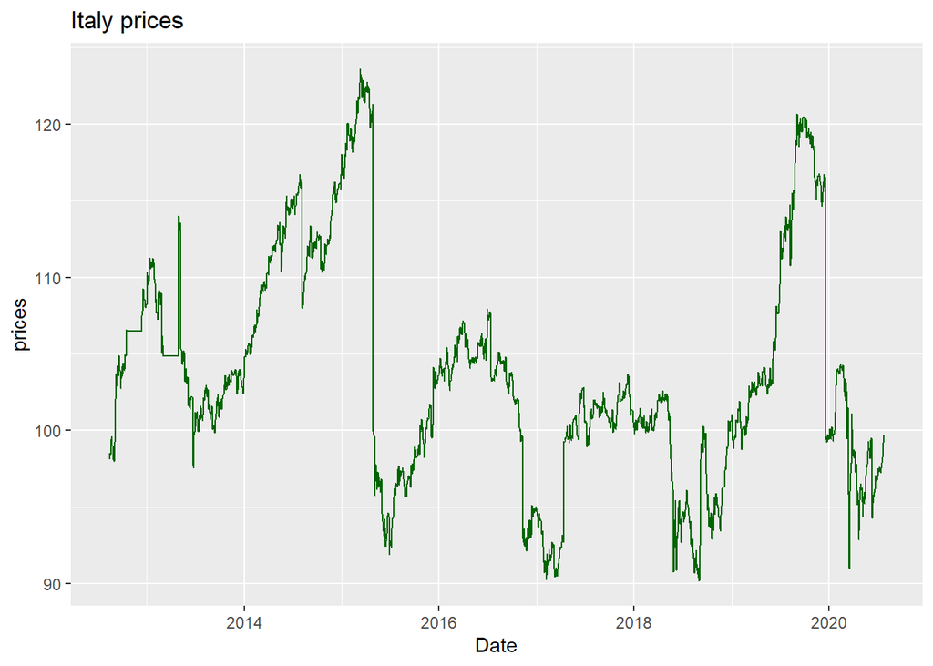

Now let’s calculate the returns of italian bond prices as they are classical computed for every financial return in the financial market:\ The multiperiod simple return is given by
$$R_{t-k: t}^*=\frac{P_t-P_{t-k}}{P_{t-k}}$$
It is straightforward to check that
$$\begin{aligned}
1+R_{t-k: t} & =\frac{P_t}{P_{t-k}} \\
& =\frac{P_t}{P_{t-1}} \frac{P_{t-1}}{P_{t-2}} \ldots
\frac{P_{t-k+1}}{P_{t-k}} \\
& =\left(1+R_t\right)\left(1+R_{t-1}\right)
\ldots\left(1+R_{t-k}\right) \\
& =\prod_{j=0}^k\left(1+R_{t-j}\right)
\end{aligned}$$
Thus, the multiperiod return can be expressed as a product of single period returns.

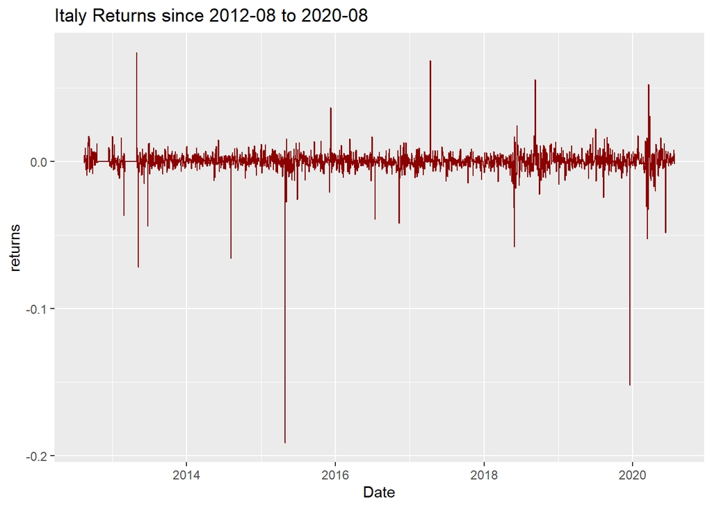

Clearly the returns shape is centered in zero with some skewed peaks, sinonimus of high volatility during certain periods.

## Check the Stationary:

Dickey-Fuller Test to check stationarity:

```r
#install.packages("urca")
library(urca)
#apply ADF test with drift
ADF_Returns = ur.df(Return.Italy, type = "drift",selectlags = "AIC" )
#summary of he test
summary(ADF_Returns)
```

```
##
## ###############################################
## # Augmented Dickey-Fuller Test Unit Root Test #
## ###############################################
##
## Test regression drift
##
##
## Call:
## lm(formula = z.diff ~ z.lag.1 + 1 + z.diff.lag)
##
## Residuals:
##       Min        1Q    Median        3Q       Max
## -0.191157 -0.002170  0.000003  0.002913  0.074144
##
## Coefficients:
##               Estimate Std. Error t value Pr(>|t|)
## (Intercept)  4.718e-06  1.966e-04   0.024    0.981
## z.lag.1     -9.949e-01  3.128e-02 -31.804   <2e-16 ***
## z.diff.lag   1.932e-02  2.239e-02   0.863    0.388
## ---
## Signif. codes:  0 '***' 0.001 '**' 0.01 '*' 0.05 '.' 0.1 ' ' 1
##
## Residual standard error: 0.008788 on 1994 degrees of freedom
## Multiple R-squared:  0.4882, Adjusted R-squared:  0.4877
## F-statistic: 951.1 on 2 and 1994 DF,  p-value: < 2.2e-16
##
##
## Value of test-statistic is: -31.8042 505.7532
##
## Critical values for test statistics:
##       1pct  5pct 10pct
## tau2 -3.43 -2.86 -2.57
## phi1  6.43  4.59  3.78
```

In absolute values figure out that test statistic is higher than both three critical values, so our Time series is $stationary$.

## Check the Presence of Volatility

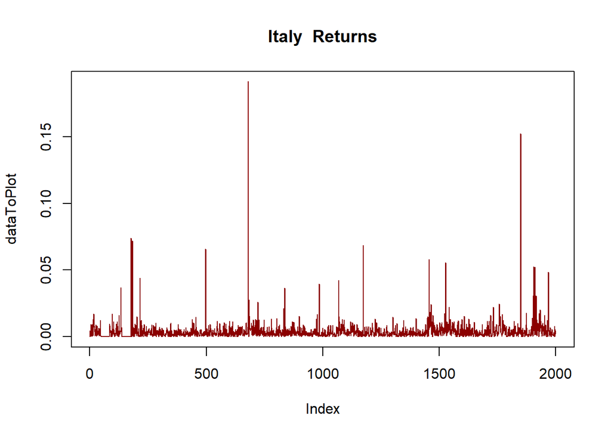

```r
library(zoo)
# plot returns with squared and absolute returns
dataToPlot = cbind( abs(Return.Italy))
colnames(dataToPlot) =  'abs(Returns)'
plot.zoo(dataToPlot, main="Italy  Returns", col="darkred")
```

Based on this graph, we can still see that there are months with very high volatility and months with very low volatility, suggesting the stochastic model for conditional volatility.

## Check Normality

Conduct Jarque-Bera test for normality:

```
##
##  Jarque Bera Test
##
## data:  Return.Italy
## X-squared = 2397354, df = 2, p-value < 2.2e-16
```

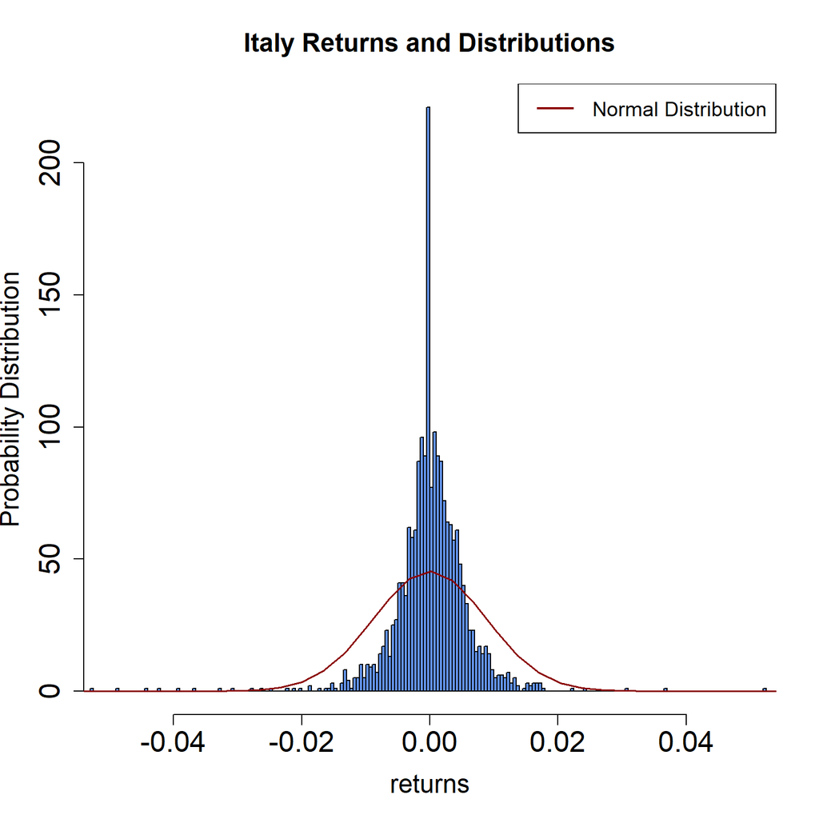

```
## [1] "The skewness is -8.04451624255572"
```

```
## [1] "The Kurtosis is 171.889837497121"
```

As we can see, the histogram of the of the returns seems to be more skewed than the normal distribution, meaning that considering the normal distribution for the returns is not a good choice. The student distribution tends to be the more adapted for this distribution. We will see if that is confirmed by the model estimation.

## Partial Auto-Correlation

From the plot below we can notice the absence of strong dependencies between lagged observations.

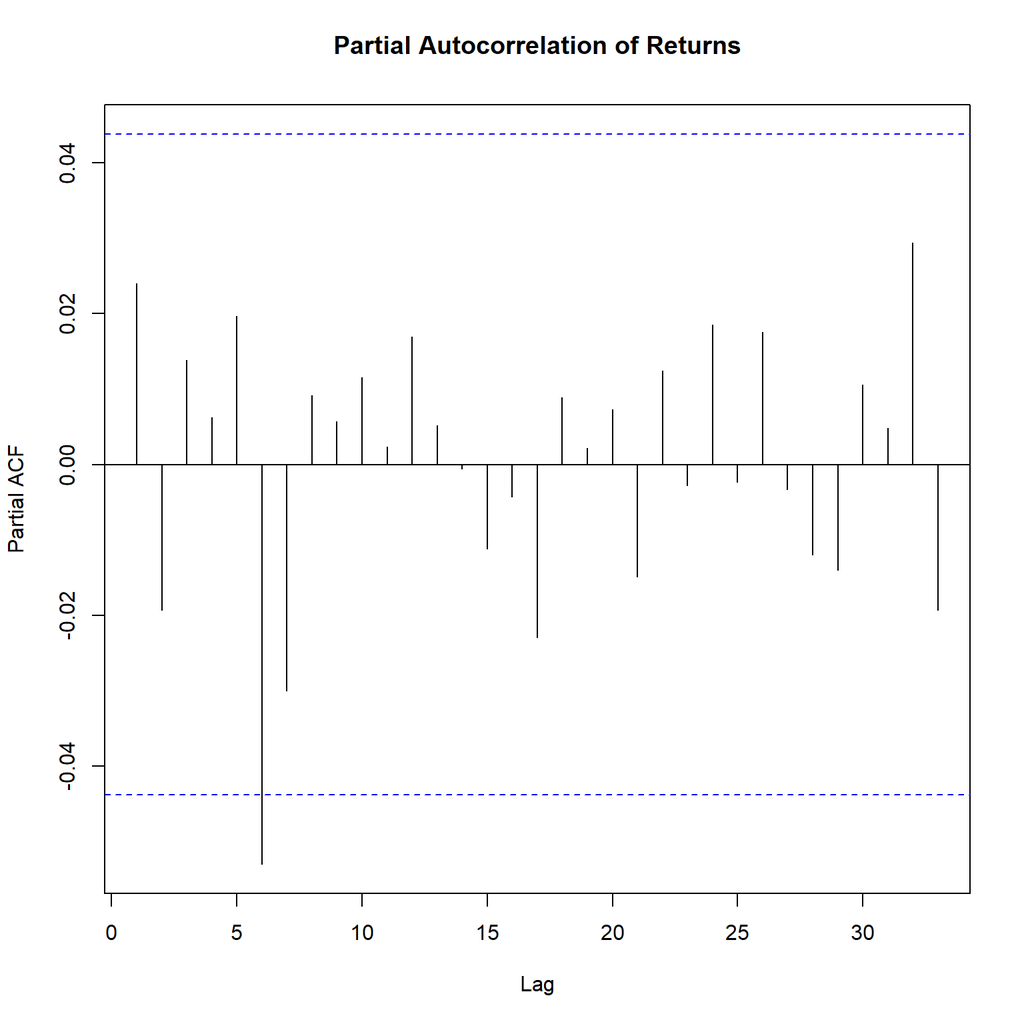

In cases where the PACF does not reveal significant dependencies, traditional time series models such as Autoregressive Integrated Moving Average (ARIMA) might not adequately capture the complexities of the underlying volatility. Neglecting to account for volatility properly can lead to erroneous predictions and sub-optimal decision-making.

## The Role of GARCH Model

In Generalized Autoregressive Conditional Heteroskedasticity (GARCH) model the conditional variance depends on both the past values of the errors and the past values of the conditional variance itself.  
GARCH models are designed to capture the time-varying nature of volatility in financial and economic time series.  
We will use a GARCH(1,1) model with $q=1$ that is a baseline literature model, due to the fact that we have not enough information about lags dependencies.

$$\begin{gathered}
y_t=c+\epsilon_t=c+\sqrt{\sigma_t^2} z_t, \quad z_t \sim N(0,1) \\
\sigma_t^2=\omega+\alpha_1 \epsilon_{t-1}^2+\ldots+\alpha_q
\epsilon_{t-q}^2+\beta_1 \sigma_{t-1}^2+\ldots+\beta_p \sigma_{t-p}^2
\end{gathered}$$
where $\omega$ is a constant value for conditional variance to guarantee that it’s positive.

In case of $\operatorname{GARCH}(1,1)$ model with a Standard Normal as $N$.
$$\begin{gathered}
y_t \sim N\left(c, \sigma_t^2\right) \\
\sigma_t=\omega+\alpha \epsilon_{t-1}^2+\beta \sigma_{t-1}^2
\end{gathered}$$

```r
model_garchN <- "
model{
      # Likelihood
      for (t in 1:T) {
        y[t] ~ dnorm(c, tau[t])   #y = c+epsilon
        tau[t] <- 1/pow(sigma[t], 2)
      }
      sigma[1] <- dunif(0,10)
      for(t in 2:T) {
        sigma[t] <- sqrt( omega + alpha * pow(y[t-1] - c, 2) + beta * pow(sigma[t-1], 2) )
      }

      # Priors
      c ~ dnorm(0.0, 0.01)
      omega ~ dunif(0, 10)
      alpha ~ dunif(0, 1)
      beta ~ dunif(0, 1)
    }"

# mydata <- list(   T = length(Return.Italy),
#                    y = Return.Italy)
#
# garch_parameters_n <- c("c", "omega", "alpha", "beta")
#
#
#
# G_T <- jags(data=mydata,
#          parameters.to.save=garch_parameters_t,
#           model.file = textConnection(model_garchT),
#           n.chains=3,
#           n.iter=1500
# )
#
# save(G_N, file = "G_N.RData")
#
load("G_N.RData")
```

```
##             mean         sd    95%_HPDL   95%_HPDU Rhat n.eff
## c     0.00001153 0.00019785 -0.00037094 0.00039441    1  2900
## omega 0.00007635 0.00000283  0.00007127 0.00008213    1  1971
## alpha 0.00674103 0.00740915  0.00000307 0.02184811    1  1881
## beta  0.01176735 0.01624590  0.00000090 0.04297312    1   943
```

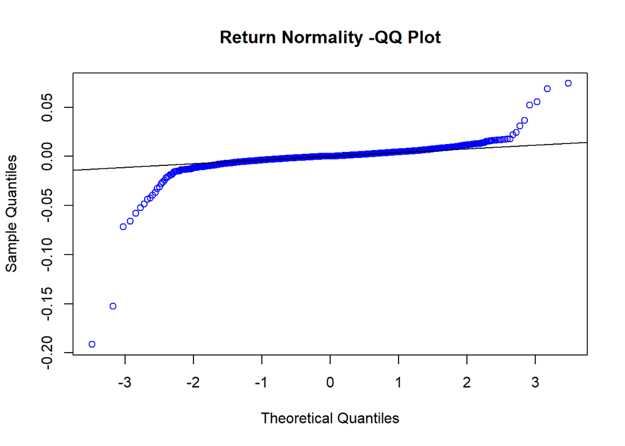

From the plot above it clear how a normal distribution it’s not feasible for our analysis. The returns are far from a normal distribution as we can notice from the tails in the qqplot.

Basically a part of this book explain while GARCH models can account for conditional heteroskedasticity, those models fail to generate sufficient excess kurtosis in asset returns, when we compare the values they imply with those estimated in the data.  
This can be seen from the fact that the standardized residuals from most GARCH models $\textit{fail to be normally distributed.}$  
Gaussian GARCH models cannot quite capture the key properties of asset returns and to address this, researchers have explored alternative distributions to model asset returns.  
One approach is to assume that the returns are IID and follow a Student’s t-distribution (t-Student) instead of a normal distribution. The t-Student distribution allows for fatter tails, meaning it assigns higher probabilities to extreme events compared to the normal distribution.

$$R_{P F, t+1}=\sigma_{t+1} z_{t+1}, \quad
z_{t+1} \sim \operatorname{IID} t(d)$$
where the residuals are IID and modeled as a t_Student.
Let’s try to model with t_Student our JAGS code:

```r
model_garchT <-
"
model{
      # Likelihood
      for (t in 1:T) {
        y[t] ~ dt(c,tau[t], 8) #high df,y are the residuals, the epsilon term!
        tau[t] <- 1/pow(sigma[t], 2)
      }
      sigma[1] ~ dunif(0,10)
      for(t in 2:T) {
        sigma[t] <- sqrt( omega + alpha * pow(y[t-1] - c, 2) + beta * pow(sigma[t-1], 2) )
      }

      # Priors
      c ~ dnorm(0 , 0.01)
      omega ~ dunif(0, 10)
      alpha ~ dunif(0, 1)
      beta ~ dunif(0, 1)
    }"
#
# mydata <- list(   T = length(Return.Italy),
#                    y = Return.Italy)
#
# garch_parameters_t <- c("c", "omega", "alpha","beta","sigma")
#
# inits <- list(
#   list("c" = 1, "omega" = 1, "alpha" = 1, "beta" = 1),
#   list("c" = 1, "omega" = 1, "alpha" = 1, "beta" = 1),
#   list("c" = 1, "omega" = 1, "alpha" = 1, "beta" = 1)
# )
#
#
#
# G_T <- jags(data=mydata,
#           parameters.to.save=garch_parameters_t,
#           model.file = textConnection(model_garchT),
#           n.chains=3,
#           n.iter=2000,
#           n.burnin = 200, # Number of iterations to remove at start
#           n.thin = 2,
#           inits=inits
# )
# #
#  save(G_T, file = 'G_T.RData')

load("G_T.RData")
```

```r
# install.packages('MCMCvis')
# library(MCMCvis)
as.data.frame(MCMCsummary(G_T,
              params = c("c", "omega", "alpha","beta"),
              HPD = TRUE,
              hpd_prob = 0.95,
              round = 8))
```

```
##             mean         sd   95%_HPDL   95%_HPDU Rhat n.eff
## c     0.00030633 0.00009860 0.00011594 0.00050526 1.00  2597
## omega 0.00000371 0.00000081 0.00000214 0.00000523 1.13   119
## alpha 0.07619738 0.01947886 0.03784324 0.11409864 1.09   228
## beta  0.66349578 0.06153793 0.55064179 0.78989793 1.15    96
```

Comparing the DIC of our models:

```r
print(G_N$BUGSoutput$DIC)
```

```
## [1] -13230.71
```

```r
print(G_T$BUGSoutput$DIC)
```

```
## [1] -15316.33
```

So, as expected, we will prefer t_Student GARCH(1,1) model.

$$FREQUENTIST$$

GARCH with T_Student distribution by a frequentest point of view using ML approach on the parameters of interest.

```r
# Specify the model
mod_specify= ugarchspec(mean.model=list(armaOrder=c(0,0)),variance.model=list(model='sGARCH',garchOrder=c(1,1)),distribution.model = 'std')
fit=ugarchfit(data=Return.Italy,spec = mod_specify,out_sample=20)
#params
parameters <- fit@fit$coef[c("mu","omega","alpha1","beta1")]
#print(fit)
as.data.frame(parameters)
```

```
##          parameters
## mu     2.927233e-04
## omega  1.241919e-05
## alpha1 2.907072e-01
## beta1  6.085736e-01
```

$$FORECAST$$

Forecasting is basically the main purposes in the GARCH origin. In our implementation we will use returns of Italy BTP in absolute value, trying to catch the volatility.

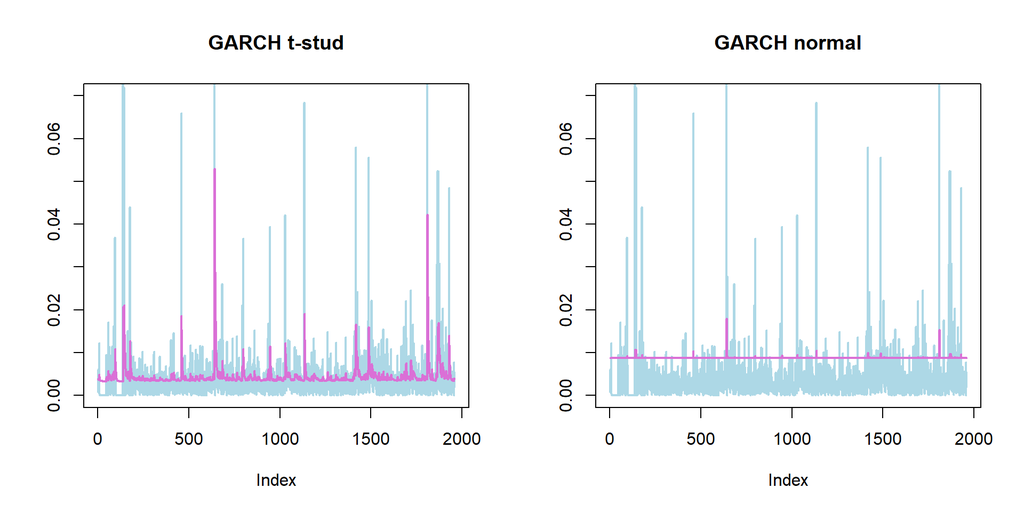

It’s visible by the plot the difference among forecasting with normal and t-student GARCH analysis. That periods of high volatility with spikes in the returns, characterized by substantial oscillations, correspond to increases in the predicted variance in t-Student approach. Instead it’s clear, and reinforce our thesis, that GARCH normal models are not able to catch variability in Bond analysis of Governments.